# Chapter 3: Linear Regression

Supposed you were asked to suggest a marketing plan for next year that will result in high product sales. Here are a few important questions we might seek to address:

1. Is there a relationship between advertising budget and sales?
2. How strong is the relationship between advertising budget and sales?
3. Which media are associated with sales?
4. How large is the association between each medium and sales?
5. How accurately can we predict future sales?
6. Is the relationship linear?
7. Is there synergy among the advertising media?

We can use linear regression to answer all of these.

# Simple Linear Regression

## Estimating the Coefficients

Least squares is commonly used and it minimizes the Residual Sum of Squares (RSS).

## Assessing the Accuracy of the Coefficient Estimates

An unbiased estimator doesn’t systematically over- or underestimate the true parameter.

The standard error tells us the average amount that this estimate differs from the actual value of $\mu$.

## Assessing the Accuracy of the Model

Residual standard error (RSE) and R-squared.

### Residual Standard Error

It is the average amount that the response will deviate from the true regression line.

### $R^2$ Statistic

It is the proportion of variance explained.

# Multiple Linear Regression

## Estimating the Regression Coefficients

## Some Important Questions

We use a confidence interval to quantify the uncertianty surrounding the average sales over a large number of cities.

A prediction interval can be used to quantify the uncertianty surrounding sales for a particular city.

# Other Considerations in the Regression Model

# The Marketing Plan

1. Is there a relationship between advertising budget and sales?

   Fit a multiple regression model.
2. How strong is the relationship between advertising budget and sales?

   Need measures of model accuracy. RSE and R-squared.
3. Which media are associated with sales?

   p-values.
4. How large is the association between each medium and sales?
5. How accurately can we predict future sales?

   We might want a prediction interval or a confidence interval.
6. Is the relationship linear?

   Residual plots
7. Is there synergy among the advertising media?

   interaction terms or polynomial terms.

# Comparison of Linear Regression with K-Nearest Neighbors

# Lab: Linear Regression

# Exercises

## Applied

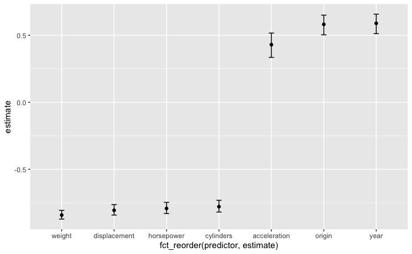